## Design Document for Balloons: roguelike game to help you bind your time

Actually, this roguelike game is quite classy: it is a roguelike, where a girl (named *Girl*) is travelling in the world of clouds: she can move through the air, and cannot - through the clouds. She gets damaged by birds and thunderclouds. Her goal is to be able to travel as long as she can: when the game is over, she returns to her real life.

# What can be extended:

- Developers who want to upgrade this game can use tile graphics. Some png_s that may appear useful are provided in ‘pictures’ folder. By now, graphics is console;
- In case the game is too easy/boring for you, you can effortlessly add new obstacles for the Girl (e.g. new bird types);
- You can also add game levels: it can be achieved by varying Bird speed and Map difficulty (you can implement your own map generation algorithm);
- You can also extend Girl’s super powers.
- You can overlay music (for instance, you can use music from the ‘music’ folder)

# Player characteristics

There can be three types of players: - Portrait of the **player A**: It’s a person who likes to think over and over all the things while playing the game. He/she does not want the game to take a lot of his/hers brain efforts. He/she wants the game to provide minimum distraction from thoughts and have something to do during the process of thinking. Player does not need any narrative line. - Portrait of the **player B**: This player needs to have some narrative line underneath the game interface. He/she is full of dreams, energy to be creative and imagine everything. This type of player needs some basic graphics to be able to create the story in her/his imagination. For this player we have a bit of ascii graphics in our game. - Portrait of the **player C**: In case the game does not become popular, the one and only player of my game is The Professor. He is fed up with checking 20 homeworks, and what he wants to see is clear architecture and something play-able. Alas.

# architecture, logic, pattern

```
Model-View-Controller architectural pattern seems to suit the best the needs of roguelike.
```

- *Model*: game rules + all roguelike game objects;
- *Controller*: units essential for interacting with user and model. They know scenarios.
- *View*: is responsible for representation. It sees only the model.

# Diagrams

Итого, у нас есть модель, которая общается с контроллером и view. На данный момент, и контроллер, и view реализованы на основе терминала.

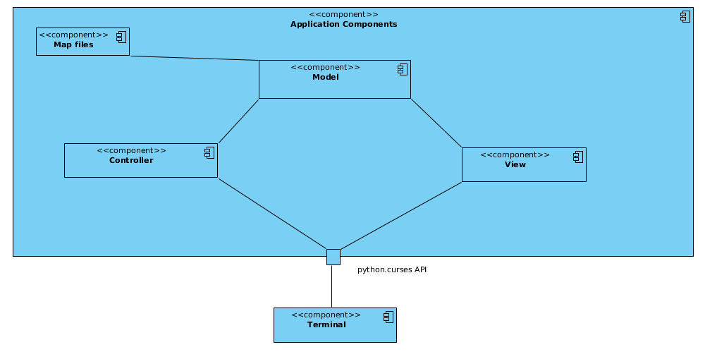

К игре прилагается набор заранее сконструированных карт, игрок проходит их поочередно: при победе на одной карте он может либо перейти на следующую, либо выйти из игры (на самом деле, выйти можно в любой момент)

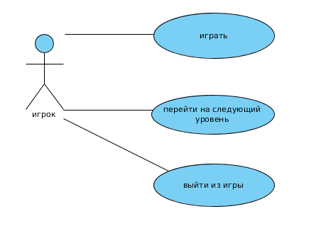

Инвентарь игрока может пополняться при переходе в клетку, содержающую элемент, который можно взять. Любой из элементов в инвентаре можно в любой момент включить, тогда он пропадает из инвентаря

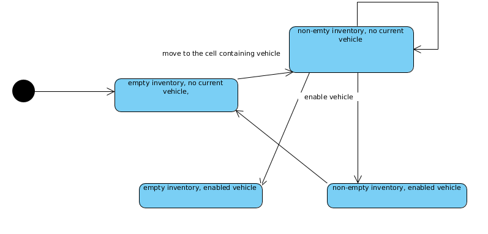

Персонаж двигается через игровое поле, теряя при этом очки хода. Цель – добраться до верхнего края карты и перейти через него, не потеряв все очки хода. При столкновении с птицей персонаж теряет 5 очков хода, с грозовым облаком – два очка

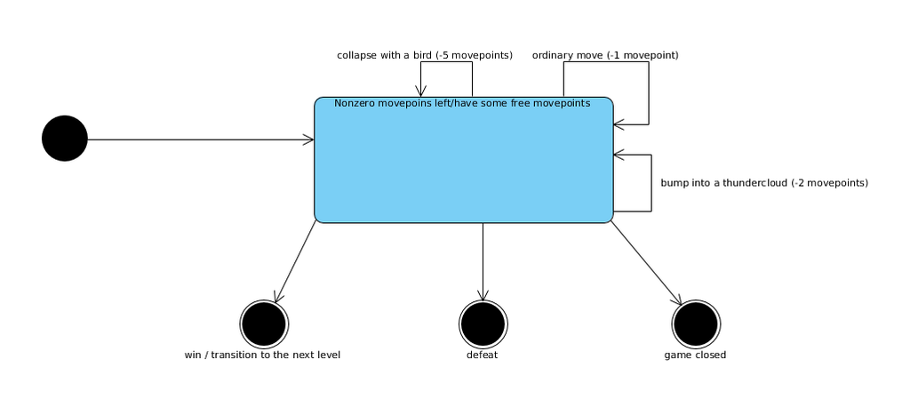

С точки зрения ООП, архитектура выгдлядит так: есть основной класс Model. Его инстанс содержит в себе:

- игровое поле (матрицу элементов абстрактного типа Cell)
- view-объект для отображения происходящего на экран (в нашем случае – типа TerminalView)
- controller-объект для получаения команд (в нашем случае – тоже на основе терминала)
- функцию для загрузки карт из пакета Класс Cell имеет слудующих наследников (варианты клеток на поле):
- Hero – персонаж
- Cloud – облако, при попытке пройти через него ничего не происходит
- ThunderCloud – облако, через которое тоже нельзя пройти, но при столкновении с ним игрок теряет два очка хода
- Bird – птица, которая движется сама, при столкновении с ней игрок теряет очки хода
- Item – элемент, который можно положить в инвентарь
- Empty – пустое поле

Класс Hero в данный момент имеет одного наследника Girl, но оставляет возможность для расширения – добавления новых типов персонажей.

Класс Item имеет двух наследников: Wings и Quadrocopter, но также оставляет возможность добавлять новые предметы.

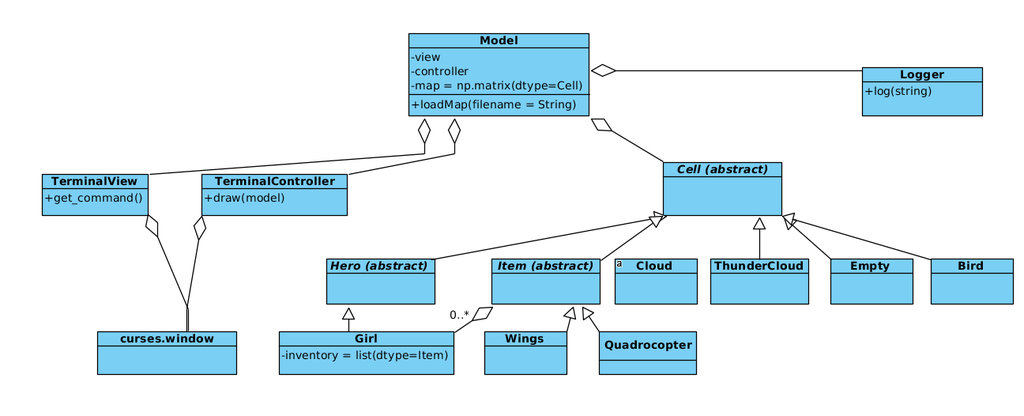